# SciBlox v0.01 Example Code - Titanic Dataset

### 1. Data Analysis

Opening files - currently CSV is only supported

Use the import * method for easier calling. (Sorry classes not done yet)

MAXROWS(x) - how many rows do you want to show (default = 15)

```python
from sciblox import *
%matplotlib inline
maxrows(5)
from jupyterthemes import jtplot
jtplot.style()
```

```python
x = read("train.csv")
read("train.csv")
```

|  | PassengerId | Survived | Pclass | Name | Sex | Age | SibSp | Parch | Ticket | Fare | Cabin | Embarked |
| --- | --- | --- | --- | --- | --- | --- | --- | --- | --- | --- | --- | --- |
| 0 | 1 | 0 | 3 | Braund, Mr. Owen Harris | male | 22.0 | 1 | 0 | A/5 21171 | 7.2500 | NaN | S |
| 1 | 2 | 1 | 1 | Cumings, Mrs. John Bradley (Florence Briggs Th... | female | 38.0 | 1 | 0 | PC 17599 | 71.2833 | C85 | C |
| ... | ... | ... | ... | ... | ... | ... | ... | ... | ... | ... | ... | ... |
| 889 | 890 | 1 | 1 | Behr, Mr. Karl Howell | male | 26.0 | 0 | 0 | 111369 | 30.0000 | C148 | C |
| 890 | 891 | 0 | 3 | Dooley, Mr. Patrick | male | 32.0 | 0 | 0 | 370376 | 7.7500 | NaN | Q |

891 rows × 12 columns

Describing and analysing your data:

```python
analyse(x)
```

|  | Type | %Missing | %Zeroes | Mean | Median | Range | IQR | Var | Mode | FreqRatio | %Unique | No.Unique |
| --- | --- | --- | --- | --- | --- | --- | --- | --- | --- | --- | --- | --- |
| Age | float | 20 | 0 | 29.7 | 28 | 79.58 | 0.13 | 211.02 | 24 | 1.11 | 0.1 | 88 |
| Cabin | str | 77 | 0 | nan | nan | nan | nan | nan | B96 B98 | 1 | 0.16 | 147 |
| Embarked | str | 0 | 0 | nan | nan | nan | nan | nan | S | 3.83 | 0 | 3 |
| Fare | float | 0 | 2 | 32.2 | 14.45 | 512.33 | 0 | 2469.44 | 8.05 | 1.02 | 0.28 | 248 |
| Name | str | 0 | 0 | nan | nan | nan | nan | nan | Abbing, Mr. Anthony | 1 | 1 | 891 |
| Parch | int | 0 | 76 | 0.38 | 0 | 6 | 0 | 0.65 | 0 | 5.75 | 0.01 | 7 |
| PassengerId | int | 0 | 0 | 446 | 446 | 890 | 4.45 | 66231 | 1 | 1 | 1 | 891 |
| Pclass | int | 0 | 0 | 2.31 | 3 | 2 | 0 | 0.7 | 3 | 2.27 | 0 | 3 |
| Sex | str | 0 | 0 | nan | nan | nan | nan | nan | male | 1.84 | 0 | 2 |
| SibSp | int | 0 | 68 | 0.52 | 0 | 8 | 0 | 1.22 | 0 | 2.91 | 0.01 | 7 |
| Survived | int | 0 | 62 | 0.38 | 0 | 1 | 0 | 0.24 | 0 | 1.61 | 0 | 2 |
| Ticket | str | 0 | 0 | nan | nan | nan | nan | nan | 1601 | 1 | 0.76 | 681 |

You can also change axis to 1 (both ANALYSE and DESCRIBE works)

```python
describe(x, axis = 1)
```

|  | Mean | Median | Range | IQR | Var | Mode | FreqRatio | %Unique | No.Unique |
| --- | --- | --- | --- | --- | --- | --- | --- | --- | --- |
| Age | 29.7 | 28 | 79.58 | 0.13 | 211.02 | 24 | 1.11 | 0.1 | 88 |
| Cabin | nan | nan | nan | nan | nan | B96 B98 | 1 | 0.16 | 147 |
| Embarked | nan | nan | nan | nan | nan | S | 3.83 | 0 | 3 |
| Fare | 32.2 | 14.45 | 512.33 | 0 | 2469.44 | 8.05 | 1.02 | 0.28 | 248 |
| Name | nan | nan | nan | nan | nan | Abbing, Mr. Anthony | 1 | 1 | 891 |
| Parch | 0.38 | 0 | 6 | 0 | 0.65 | 0 | 5.75 | 0.01 | 7 |
| PassengerId | 446 | 446 | 890 | 4.45 | 66231 | 1 | 1 | 1 | 891 |
| Pclass | 2.31 | 3 | 2 | 0 | 0.7 | 3 | 2.27 | 0 | 3 |
| Sex | nan | nan | nan | nan | nan | male | 1.84 | 0 | 2 |
| SibSp | 0.52 | 0 | 8 | 0 | 1.22 | 0 | 2.91 | 0.01 | 7 |
| Survived | 0.38 | 0 | 1 | 0 | 0.24 | 0 | 1.61 | 0 | 2 |
| Ticket | nan | nan | nan | nan | nan | 1601 | 1 | 0.76 | 681 |

You can output the analysis to a dataframe

```python
analyse(x, colour = False)
```

|  | Type | %Missing | %Zeroes | Mean | Median | Range | IQR | Var | Mode | FreqRatio | %Unique | No.Unique |
| --- | --- | --- | --- | --- | --- | --- | --- | --- | --- | --- | --- | --- |
| Age | float | 20 | 0 | 29.70 | 28.0 | 79.58 | 0.13 | 211.02 | 24 | 1.11 | 0.10 | 88.0 |
| Cabin | str | 77 | 0 | NaN | NaN | NaN | NaN | NaN | B96 B98 | 1.00 | 0.16 | 147.0 |
| ... | ... | ... | ... | ... | ... | ... | ... | ... | ... | ... | ... | ... |
| Survived | int | 0 | 62 | 0.38 | 0.0 | 1.00 | 0.00 | 0.24 | 0 | 1.61 | 0.00 | 2.0 |
| Ticket | str | 0 | 0 | NaN | NaN | NaN | NaN | NaN | 1601 | 1.00 | 0.76 | 681.0 |

12 rows × 12 columns

You can also check the data's Frequency Ratio and Variance Thresholds.

It'll try to get outliers highlighted.

```python
varcheck(x)
```

|  | FreqRatio | %Unique | Var | VarGood? |
| --- | --- | --- | --- | --- |
| Age | 1.11 | 0.099 | 211.019 | True |
| Cabin | 1 | 0.165 | nan | nan |
| Embarked | 3.83 | 0.003 | nan | nan |
| Fare | 1.02 | 0.278 | 2469.44 | True |
| Name | 1 | 1 | nan | nan |
| Parch | 5.75 | 0.008 | 0.65 | True |
| PassengerId | 1 | 1 | 66231 | True |
| Pclass | 2.27 | 0.003 | 0.699 | True |
| Sex | 1.84 | 0.002 | nan | nan |
| SibSp | 2.91 | 0.008 | 1.216 | True |
| Survived | 1.61 | 0.002 | 0.237 | True |
| Ticket | 1 | 0.764 | nan | nan |

You can specify thresholds:

```python
varcheck(x, freq = "mean", unique = 0.01)
```

|  | FreqRatio | %Unique | Var | VarGood? | FreqRatioGood? | %UniqueGood? | Good? |
| --- | --- | --- | --- | --- | --- | --- | --- |
| Age | 1.11 | 0.099 | 211.019 | True | True | True | True |
| Cabin | 1 | 0.165 | nan | nan | True | True | True |
| Embarked | 3.83 | 0.003 | nan | nan | False | False | False |
| Fare | 1.02 | 0.278 | 2469.44 | True | True | True | True |
| Name | 1 | 1 | nan | nan | True | True | True |
| Parch | 5.75 | 0.008 | 0.65 | True | False | False | False |
| PassengerId | 1 | 1 | 66231 | True | True | True | True |
| Pclass | 2.27 | 0.003 | 0.699 | True | True | False | False |
| Sex | 1.84 | 0.002 | nan | nan | True | False | False |
| SibSp | 2.91 | 0.008 | 1.216 | True | True | False | False |
| Survived | 1.61 | 0.002 | 0.237 | True | True | False | False |
| Ticket | 1 | 0.764 | nan | nan | True | True | True |

You can also output the correlation matrix:

```python
corr(x)
```

|  | PassengerId | Survived | Pclass | Age | SibSp | Parch | Fare |
| --- | --- | --- | --- | --- | --- | --- | --- |
| PassengerId | 1 | -0.005 | -0.035 | 0.037 | -0.058 | -0.0017 | 0.013 |
| Survived | -0.005 | 1 | -0.34 | -0.077 | -0.035 | 0.082 | 0.26 |
| Pclass | -0.035 | -0.34 | 1 | -0.37 | 0.083 | 0.018 | -0.55 |
| Age | 0.037 | -0.077 | -0.37 | 1 | -0.31 | -0.19 | 0.096 |
| SibSp | -0.058 | -0.035 | 0.083 | -0.31 | 1 | 0.41 | 0.16 |
| Parch | -0.0017 | 0.082 | 0.018 | -0.19 | 0.41 | 1 | 0.22 |
| Fare | 0.013 | 0.26 | -0.55 | 0.096 | 0.16 | 0.22 | 1 |

```python
corr(x, table = True)
```

|  | PassengerId | Survived | Pclass | Age | SibSp | Parch | Fare |
| --- | --- | --- | --- | --- | --- | --- | --- |
| PassengerId | 1.000000 | -0.005007 | -0.035144 | 0.036847 | -0.057527 | -0.001652 | 0.012658 |
| Survived | -0.005007 | 1.000000 | -0.338481 | -0.077221 | -0.035322 | 0.081629 | 0.257307 |
| ... | ... | ... | ... | ... | ... | ... | ... |
| Parch | -0.001652 | 0.081629 | 0.018443 | -0.189119 | 0.414838 | 1.000000 | 0.216225 |
| Fare | 0.012658 | 0.257307 | -0.549500 | 0.096067 | 0.159651 | 0.216225 | 1.000000 |

7 rows × 7 columns

```python
remcor(x, threshold = 0.5)
```

|  | PassengerId | Survived | Pclass | Name | Sex | Age | SibSp | Parch | Ticket | Fare | Cabin | Embarked |
| --- | --- | --- | --- | --- | --- | --- | --- | --- | --- | --- | --- | --- |
| 0 | 1 | 0 | 3 | Braund, Mr. Owen Harris | male | 22.0 | 1 | 0 | A/5 21171 | 7.2500 | NaN | S |
| 1 | 2 | 1 | 1 | Cumings, Mrs. John Bradley (Florence Briggs Th... | female | 38.0 | 1 | 0 | PC 17599 | 71.2833 | C85 | C |
| ... | ... | ... | ... | ... | ... | ... | ... | ... | ... | ... | ... | ... |
| 889 | 890 | 1 | 1 | Behr, Mr. Karl Howell | male | 26.0 | 0 | 0 | 111369 | 30.0000 | C148 | C |
| 890 | 891 | 0 | 3 | Dooley, Mr. Patrick | male | 32.0 | 0 | 0 | 370376 | 7.7500 | NaN | Q |

891 rows × 12 columns

### 2. Data Visualisations

Plotting is easy. (Currently X,Y,Factor supported)

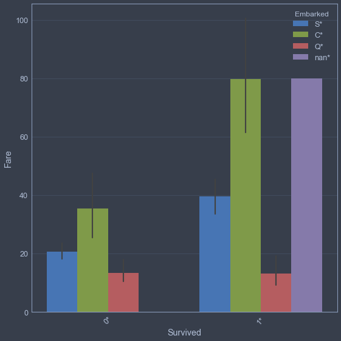

```python
plot(x = "Survived", y = "Fare", factor = "Embarked", data = x)
```

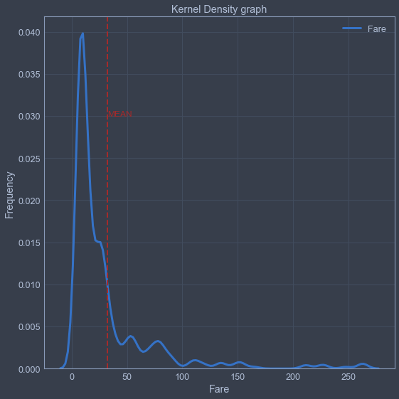

```python
plot(x = "Fare", data = x)
```

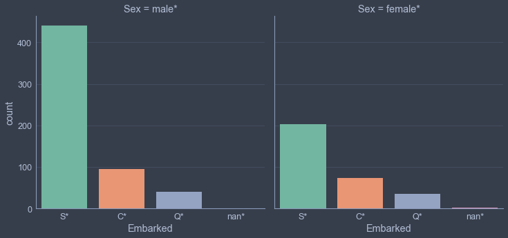

```python
plot(x = "Embarked", y = "Sex", data = x)
```

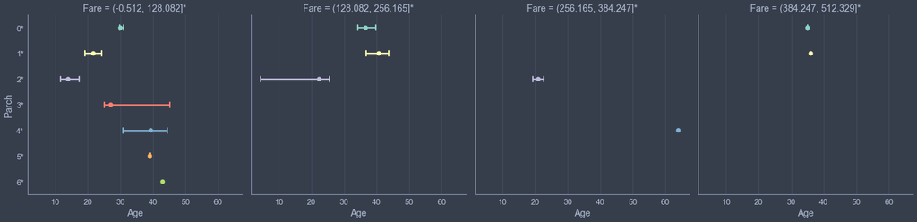

```python
plot(x = "Age", y = "Parch", factor = "Fare", data = x)
```

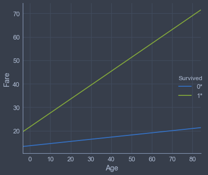

```python
plot(x = "Age", y = "Fare", factor = "Survived", data = x)
```

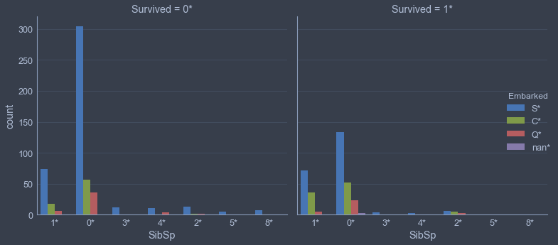

```python
plot(x = "SibSp", y = "Embarked", factor = "Survived", data = x)
```

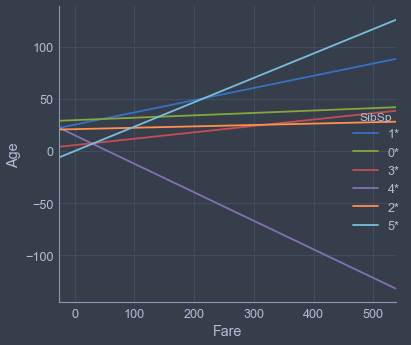

```python
plot(x = "Fare", y = "Age", factor = "SibSp", data = x)
```

### 3. Data Cleaning

Use the FILLNA function: (Fancy Impute package, sklearn and xgboost)

```python
%%capture
knn = fillna(x)
```

```python
knn
```

|  | PassengerId | Survived | Pclass | Name | Sex | Age | SibSp | Parch | Ticket | Fare | Cabin | Embarked |
| --- | --- | --- | --- | --- | --- | --- | --- | --- | --- | --- | --- | --- |
| 0 | 1 | 0 | 3 | Braund, Mr. Owen Harris | male | 22.0 | 1 | 0 | A/5 21171 | 7.2500 | Missing_Data | S |
| 1 | 2 | 1 | 1 | Cumings, Mrs. John Bradley (Florence Briggs Th... | female | 38.0 | 1 | 0 | PC 17599 | 71.2833 | C85 | C |
| ... | ... | ... | ... | ... | ... | ... | ... | ... | ... | ... | ... | ... |
| 889 | 890 | 1 | 1 | Behr, Mr. Karl Howell | male | 26.0 | 0 | 0 | 111369 | 30.0000 | C148 | C |
| 890 | 891 | 0 | 3 | Dooley, Mr. Patrick | male | 32.0 | 0 | 0 | 370376 | 7.7500 | Missing_Data | Q |

891 rows × 12 columns

You can try MICE / BPCA / SVD methods

```python
%%capture
svd = fillna(x, method = "svd")
bpca = fillna(x, method = "bpca")
mice = fillna(x, method = "mice", mice = "boost")
fillna(x, method = "mice", mice = "tree")
fillna(x, method = "mice", mice = "linear")
```

```python
mice
```

|  | PassengerId | Survived | Pclass | Name | Sex | Age | SibSp | Parch | Ticket | Fare | Cabin | Embarked |
| --- | --- | --- | --- | --- | --- | --- | --- | --- | --- | --- | --- | --- |
| 0 | 1 | 0 | 3 | Braund, Mr. Owen Harris | male | 22.0 | 1 | 0 | A/5 21171 | 7.2500 | Missing_Data | S |
| 1 | 2 | 1 | 1 | Cumings, Mrs. John Bradley (Florence Briggs Th... | female | 38.0 | 1 | 0 | PC 17599 | 71.2833 | C85 | C |
| ... | ... | ... | ... | ... | ... | ... | ... | ... | ... | ... | ... | ... |
| 889 | 890 | 1 | 1 | Behr, Mr. Karl Howell | male | 26.0 | 0 | 0 | 111369 | 30.0000 | C148 | C |
| 890 | 891 | 0 | 3 | Dooley, Mr. Patrick | male | 32.0 | 0 | 0 | 370376 | 7.7500 | Missing_Data | Q |

891 rows × 12 columns

You can also get dummies

```python
to_cont(x)
```

|  | Age | Age_nan | Cabin_nan | Embarked_C | Embarked_Q | Embarked_S | Fare | Parch | PassengerId | Pclass | Sex_female | Sex_male | SibSp | Survived |
| --- | --- | --- | --- | --- | --- | --- | --- | --- | --- | --- | --- | --- | --- | --- |
| 0 | 22.0 | 0 | 1 | 0.0 | 0.0 | 1.0 | 7.2500 | 0 | 1 | 3 | 0 | 1 | 1 | 0 |
| 1 | 38.0 | 0 | 0 | 1.0 | 0.0 | 0.0 | 71.2833 | 0 | 2 | 1 | 1 | 0 | 1 | 1 |
| ... | ... | ... | ... | ... | ... | ... | ... | ... | ... | ... | ... | ... | ... | ... |
| 889 | 26.0 | 0 | 0 | 1.0 | 0.0 | 0.0 | 30.0000 | 0 | 890 | 1 | 0 | 1 | 0 | 1 |
| 890 | 32.0 | 0 | 1 | 0.0 | 1.0 | 0.0 | 7.7500 | 0 | 891 | 3 | 0 | 1 | 0 | 0 |

891 rows × 14 columns

```python
to_cont(x, dummies = False)
```

|  | Age | Age_nan | Cabin_nan | Embarked | Fare | Parch | PassengerId | Pclass | Sex | SibSp | Survived |
| --- | --- | --- | --- | --- | --- | --- | --- | --- | --- | --- | --- |
| 0 | 22.0 | 0 | 1 | 2.0 | 7.2500 | 0 | 1 | 3 | 1 | 1 | 0 |
| 1 | 38.0 | 0 | 0 | 1.0 | 71.2833 | 0 | 2 | 1 | 0 | 1 | 1 |
| ... | ... | ... | ... | ... | ... | ... | ... | ... | ... | ... | ... |
| 889 | 26.0 | 0 | 0 | 1.0 | 30.0000 | 0 | 890 | 1 | 1 | 0 | 1 |
| 890 | 32.0 | 0 | 1 | 0.0 | 7.7500 | 0 | 891 | 3 | 1 | 0 | 0 |

891 rows × 11 columns

```python
codes, df = to_cont(x, dummies = False, class_max = "all", return_codes = True)
```

```python
codes["Embarked"]
```

```
{'C': 1, 'Q': 0, 'S': 2}
```

### 4. Data Mining

Getting strings is easy. Let's say we want to get Mr/Mrs.. honorifics

Everything is sequential

```python
maxrows(4)
get(x["Name"])
```

```
0                                Braund, Mr. Owen Harris
1      Cumings, Mrs. John Bradley (Florence Briggs Th...
                             ...
889                                Behr, Mr. Karl Howell
890                                  Dooley, Mr. Patrick
Name: Name, Length: 891, dtype: object
```

```python
get(x["Name"], split = ", ")
```

```
0                              [Braund, Mr. Owen Harris]
1      [Cumings, Mrs. John Bradley (Florence Briggs T...
                             ...
889                              [Behr, Mr. Karl Howell]
890                                [Dooley, Mr. Patrick]
Name: Name, Length: 891, dtype: object
```

*PLEASE TYPE SPLIT1 or SPLIT2 etc when you have more than 1 SPLIT*

```python
get(x["Name"], split = ", ", loc = 1, split1 = ". ", loc1 = 0, df = True)
```

|  | 0 |
| --- | --- |
| 0 | Mr |
| 1 | Mrs |
| ... | ... |
| 889 | Mr |
| 890 | Mr |

891 rows × 1 columns

You can also get word frequencies

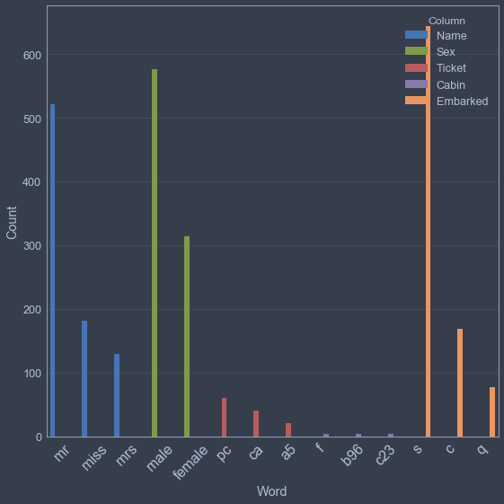

```python
wordfreq(x)
```

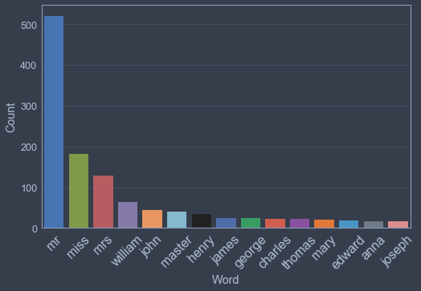

```python
wordfreq(x["Name"], first = 15)
```

```python
wordfreq(x["Name"], first = 5, hist = False)
```

|  | Word | Count |
| --- | --- | --- |
| 0 | mr | 521 |
| 1 | miss | 182 |
| ... | ... | ... |
| 3 | william | 64 |
| 4 | john | 44 |

5 rows × 2 columns

You can also get new columns from wordfreq

```python
getwords(x, first = 5)
```

|  | PassengerId | Survived | Pclass | Name | Sex | Age | SibSp | Parch | Ticket | Fare | Cabin | Embarked | Count=mr | Count=male | Count=pc | Count=f | Count=s |
| --- | --- | --- | --- | --- | --- | --- | --- | --- | --- | --- | --- | --- | --- | --- | --- | --- | --- |
| 0 | 1 | 0 | 3 | Braund, Mr. Owen Harris | male | 22.0 | 1 | 0 | A/5 21171 | 7.2500 | NaN | S | 1 | 1 | 0 | NaN | 1.0 |
| 1 | 2 | 1 | 1 | Cumings, Mrs. John Bradley (Florence Briggs Th... | female | 38.0 | 1 | 0 | PC 17599 | 71.2833 | C85 | C | 1 | 1 | 1 | 0.0 | 0.0 |
| ... | ... | ... | ... | ... | ... | ... | ... | ... | ... | ... | ... | ... | ... | ... | ... | ... | ... |
| 889 | 890 | 1 | 1 | Behr, Mr. Karl Howell | male | 26.0 | 0 | 0 | 111369 | 30.0000 | C148 | C | 1 | 1 | 0 | 0.0 | 0.0 |
| 890 | 891 | 0 | 3 | Dooley, Mr. Patrick | male | 32.0 | 0 | 0 | 370376 | 7.7500 | NaN | Q | 1 | 1 | 0 | NaN | 0.0 |

891 rows × 17 columns

You can also discretise columns:

```python
discretise(x["Fare"], n = 5)
```

```
0        (-0.001, 7.854]
1      (39.688, 512.329]
             ...
889     (21.679, 39.688]
890      (-0.001, 7.854]
Name: Fare, Length: 891, dtype: category
Categories (5, interval[float64]): [(-0.001, 7.854] < (7.854, 10.5] < (10.5, 21.679] < (21.679, 39.688] < (39.688, 512.329]]
```

```python
discretise(x["Fare"], n = 10, codes = True, smooth = False)
```

```
0      0
1      1
      ..
889    0
890    0
Name: Fare, Length: 891, dtype: int64
```

You can also flatten columns:

```python
flatten(x["Name"], lower = False)[0:10]
```

```
['Braund',
 'Mr',
 'Owen',
 'Harris',
 'Cumings',
 'Mrs',
 'John',
 'Bradley',
 'Florence',
 'Briggs']
```

### 5. Data Descriptions

Getting columns and indexes is easy:

```python
columns(x)
```

```
['PassengerId',
 'Survived',
 'Pclass',
 'Name',
 'Sex',
 'Age',
 'SibSp',
 'Parch',
 'Ticket',
 'Fare',
 'Cabin',
 'Embarked']
```

```python
conts(x)
```

```
['PassengerId', 'Survived', 'Pclass', 'Age', 'SibSp', 'Parch', 'Fare']
```

```python
strs(x)
```

```
['Name', 'Sex', 'Ticket', 'Cabin', 'Embarked']
```

```python
index(x)[0:5]
```

```
[0, 1, 2, 3, 4]
```

Getting uniques is easy:

```python
unique(x)["Embarked"]
```

```
['S', 'C', 'Q', nan]
```

```python
cunique(x)["Embarked"]
```

```
S    644
C    168
Q     77
Name: Embarked, dtype: int64
```

```python
punique(x)
```

```
PassengerId    1.000
Survived       0.002
               ...
Cabin          0.165
Embarked       0.003
Length: 12, dtype: float64
```

```python
nunique(x["Parch"])
```

```
7
```

You can sort a dataframe or any datatype:

```python
sort(x, by = ["Name"])
```

|  | PassengerId | Survived | Pclass | Name | Sex | Age | SibSp | Parch | Ticket | Fare | Cabin | Embarked |
| --- | --- | --- | --- | --- | --- | --- | --- | --- | --- | --- | --- | --- |
| 845 | 846 | 0 | 3 | Abbing, Mr. Anthony | male | 42.0 | 0 | 0 | C.A. 5547 | 7.55 | NaN | S |
| 746 | 747 | 0 | 3 | Abbott, Mr. Rossmore Edward | male | 16.0 | 1 | 1 | C.A. 2673 | 20.25 | NaN | S |
| ... | ... | ... | ... | ... | ... | ... | ... | ... | ... | ... | ... | ... |
| 153 | 154 | 0 | 3 | van Billiard, Mr. Austin Blyler | male | 40.5 | 0 | 2 | A/5. 851 | 14.50 | NaN | S |
| 868 | 869 | 0 | 3 | van Melkebeke, Mr. Philemon | male | NaN | 0 | 0 | 345777 | 9.50 | NaN | S |

891 rows × 12 columns

```python
sort([1,2,3,4,1,2])
```

```
[1, 1, 2, 2, 3, 4]
```

You can also sort by frequency then length:

```python
fsort(x, by = "Name")
```

|  | PassengerId | Survived | Pclass | Name | Sex | Age | SibSp | Parch | Ticket | Fare | Cabin | Embarked |
| --- | --- | --- | --- | --- | --- | --- | --- | --- | --- | --- | --- | --- |
| 692 | 693 | 1 | 3 | Lam, Mr. Ali | male | NaN | 0 | 0 | 1601 | 56.4958 | NaN | S |
| 826 | 827 | 0 | 3 | Lam, Mr. Len | male | NaN | 0 | 0 | 1601 | 56.4958 | NaN | S |
| ... | ... | ... | ... | ... | ... | ... | ... | ... | ... | ... | ... | ... |
| 427 | 428 | 1 | 2 | Phillips, Miss. Kate Florence ("Mrs Kate Louis... | female | 19.0 | 0 | 0 | 250655 | 26.0000 | NaN | S |
| 307 | 308 | 1 | 1 | Penasco y Castellana, Mrs. Victor de Satode (M... | female | 17.0 | 1 | 0 | PC 17758 | 108.9000 | C65 | C |

891 rows × 12 columns

Other methods:

```python
tail(x)
head(x)
```

|  | PassengerId | Survived | Pclass | Name | Sex | Age | SibSp | Parch | Ticket | Fare | Cabin | Embarked |
| --- | --- | --- | --- | --- | --- | --- | --- | --- | --- | --- | --- | --- |
| 0 | 1 | 0 | 3 | Braund, Mr. Owen Harris | male | 22.0 | 1 | 0 | A/5 21171 | 7.2500 | NaN | S |
| 1 | 2 | 1 | 1 | Cumings, Mrs. John Bradley (Florence Briggs Th... | female | 38.0 | 1 | 0 | PC 17599 | 71.2833 | C85 | C |
| ... | ... | ... | ... | ... | ... | ... | ... | ... | ... | ... | ... | ... |
| 3 | 4 | 1 | 1 | Futrelle, Mrs. Jacques Heath (Lily May Peel) | female | 35.0 | 1 | 0 | 113803 | 53.1000 | C123 | S |
| 4 | 5 | 0 | 3 | Allen, Mr. William Henry | male | 35.0 | 0 | 0 | 373450 | 8.0500 | NaN | S |

5 rows × 12 columns

```python
random(x)
```

|  | PassengerId | Survived | Pclass | Name | Sex | Age | SibSp | Parch | Ticket | Fare | Cabin | Embarked |
| --- | --- | --- | --- | --- | --- | --- | --- | --- | --- | --- | --- | --- |
| 428 | 429 | 0 | 3 | Flynn, Mr. James | male | NaN | 0 | 0 | 364851 | 7.7500 | NaN | Q |
| 285 | 286 | 0 | 3 | Stankovic, Mr. Ivan | male | 33.0 | 0 | 0 | 349239 | 8.6625 | NaN | C |
| ... | ... | ... | ... | ... | ... | ... | ... | ... | ... | ... | ... | ... |
| 395 | 396 | 0 | 3 | Johansson, Mr. Erik | male | 22.0 | 0 | 0 | 350052 | 7.7958 | NaN | S |
| 882 | 883 | 0 | 3 | Dahlberg, Miss. Gerda Ulrika | female | 22.0 | 0 | 0 | 7552 | 10.5167 | NaN | S |

5 rows × 12 columns

```python
shape(x)
```

```
(891, 12)
```

You can also subset NULL rows / not NULL:

```python
isnull(x)
notnull(x, subset = "Fare")
```

|  | PassengerId | Survived | Pclass | Name | Sex | Age | SibSp | Parch | Ticket | Fare | Cabin | Embarked |
| --- | --- | --- | --- | --- | --- | --- | --- | --- | --- | --- | --- | --- |
| 1 | 2 | 1 | 1 | Cumings, Mrs. John Bradley (Florence Briggs Th... | female | 38.0 | 1 | 0 | PC 17599 | 71.2833 | C85 | C |
| 3 | 4 | 1 | 1 | Futrelle, Mrs. Jacques Heath (Lily May Peel) | female | 35.0 | 1 | 0 | 113803 | 53.1000 | C123 | S |
| ... | ... | ... | ... | ... | ... | ... | ... | ... | ... | ... | ... | ... |
| 887 | 888 | 1 | 1 | Graham, Miss. Margaret Edith | female | 19.0 | 0 | 0 | 112053 | 30.0000 | B42 | S |
| 889 | 890 | 1 | 1 | Behr, Mr. Karl Howell | male | 26.0 | 0 | 0 | 111369 | 30.0000 | C148 | C |

183 rows × 12 columns

Cleaning columns is easy:

```python
x["Pclass"] = float(x["Pclass"])
```

```python
x["Pclass"]
```

```
0      3.0
1      1.0
      ...
889    1.0
890    3.0
Name: Pclass, Length: 891, dtype: float64
```

```python
clean(x["Pclass"])[0:10]
```

```
array([3, 1, 3, 1, 3, 3, 1, 3, 3, 2], dtype=int64)
```

### 6. Data Wrangling

Excluding columns, including columns is easy:

```python
inc(x, "Name")
exc(x, "Name")
```

|  | Age | Cabin | Embarked | Fare | Parch | PassengerId | Pclass | Sex | SibSp | Survived | Ticket |
| --- | --- | --- | --- | --- | --- | --- | --- | --- | --- | --- | --- |
| 0 | 22.0 | NaN | S | 7.2500 | 0 | 1 | 3.0 | male | 1 | 0 | A/5 21171 |
| 1 | 38.0 | C85 | C | 71.2833 | 0 | 2 | 1.0 | female | 1 | 1 | PC 17599 |
| ... | ... | ... | ... | ... | ... | ... | ... | ... | ... | ... | ... |
| 889 | 26.0 | C148 | C | 30.0000 | 0 | 890 | 1.0 | male | 0 | 1 | 111369 |
| 890 | 32.0 | NaN | Q | 7.7500 | 0 | 891 | 3.0 | male | 0 | 0 | 370376 |

891 rows × 11 columns

Reversing columns, reversing lists and reversing dictionaries + reversing booleans:

```python
df = copy(x)
reverse(x["Name"])
```

```
890                                  Dooley, Mr. Patrick
889                                Behr, Mr. Karl Howell
                             ...
1      Cumings, Mrs. John Bradley (Florence Briggs Th...
0                                Braund, Mr. Owen Harris
Name: Name, Length: 891, dtype: object
```

```python
phone = {"Daniel":1234,"Michael":32432}
reverse(phone)
```

```
{1234: 'Daniel', 32432: 'Michael'}
```

```python
(x["Survived"] == 0)
```

```
0       True
1      False
       ...
889    False
890     True
Name: Survived, Length: 891, dtype: bool
```

```python
reverse(x["Survived"] == 0)
```

```
0      False
1       True
       ...
889     True
890    False
Name: Survived, Length: 891, dtype: bool
```

Horizontal concat, Vertical concat:

```python
df = x[conts(x)]
hcat(mean(df), median(df), iqr(df), var(df), std(df))
```

|  | 0 | 0 | 0 | 0 | 0 |
| --- | --- | --- | --- | --- | --- |
| PassengerId | 446.000000 | 446.0000 | 445.0000 | 66231.000000 | 257.353842 |
| Survived | 0.383838 | 0.0000 | 1.0000 | 0.236772 | 0.486592 |
| ... | ... | ... | ... | ... | ... |
| Parch | 0.381594 | 0.0000 | 0.0000 | 0.649728 | 0.806057 |
| Fare | 32.204208 | 14.4542 | 23.0896 | 2469.436846 | 49.693429 |

7 rows × 5 columns

```python
df = x[strs(x)]
vcat(nunqiue(x),freqratio(x),count(x))
```

|  | 0 |
| --- | --- |
| PassengerId | 891.0 |
| Survived | 2.0 |
| ... | ... |
| Cabin | 204.0 |
| Embarked | 889.0 |

36 rows × 1 columns

Resetting indexes:

```python
reset(x)
```

|  | index | PassengerId | Survived | Pclass | Name | Sex | Age | SibSp | Parch | Ticket | Fare | Cabin | Embarked |
| --- | --- | --- | --- | --- | --- | --- | --- | --- | --- | --- | --- | --- | --- |
| 0 | 0 | 1 | 0 | 3.0 | Braund, Mr. Owen Harris | male | 22.0 | 1 | 0 | A/5 21171 | 7.2500 | NaN | S |
| 1 | 1 | 2 | 1 | 1.0 | Cumings, Mrs. John Bradley (Florence Briggs Th... | female | 38.0 | 1 | 0 | PC 17599 | 71.2833 | C85 | C |
| ... | ... | ... | ... | ... | ... | ... | ... | ... | ... | ... | ... | ... | ... |
| 889 | 889 | 890 | 1 | 1.0 | Behr, Mr. Karl Howell | male | 26.0 | 0 | 0 | 111369 | 30.0000 | C148 | C |
| 890 | 890 | 891 | 0 | 3.0 | Dooley, Mr. Patrick | male | 32.0 | 0 | 0 | 370376 | 7.7500 | NaN | Q |

891 rows × 13 columns

### 7. Mathematics and Statistics

Easy linear algebra:

```python
C = array([1,2,3],[1,2,3])
A = matrix([1,2,3], [1,2,4], [5,3,2])
B = matrix("1 2 3\
            7 673 2\
            21321 22 3")
B
```

```
matrix([[    1,     2,     3],
        [    7,   673,     2],
        [21321,    22,     3]], dtype=int64)
```

```python
T(B)
```

```
matrix([[    1,     7, 21321],
        [    2,   673,    22],
        [    3,     2,     3]], dtype=int64)
```

```python
tile(C,1,2)
```

```
array([[1, 2, 3, 1, 2, 3],
       [1, 2, 3, 1, 2, 3]])
```

```python
J(5)*Z(5)*I(5)
```

```
array([[ 0.,  0.,  0.,  0.,  0.],
       [ 0.,  0.,  0.,  0.,  0.],
       [ 0.,  0.,  0.,  0.,  0.],
       [ 0.,  0.,  0.,  0.,  0.],
       [ 0.,  0.,  0.,  0.,  0.]])
```

```python
qnorm(95)
```

```
1.6448536269514722
```

```python
pnorm(1.65)
```

```
0.50658224895572213
```

```python
CI(q = 95, data = x["Fare"])
```

```
(28.941274632718805, 35.467141304430399)
```

```python
M(tr(A)*diag(A))
```

```
matrix([[ 5, 10, 10]])
```